# STATS 506 Group 4 Project

Huayu Li, Kai Liu, Xiru Lyu

December 08, 2019

# Introduction

According to [Centers for Disease Control and Prevention](https://www.cdc.gov/cholesterol/facts.htm), in 2015-2016, more than 12% of adults at the age of 20 and above in the United States have cholesterol levels higher than 240mg/ml. A high cholesterol level is one of the major risk factors for coronary heart disease, heart attack and stroke. While there are two types of cholesterol, low-density lipoprotein (LDL) is known as the “bad” one that leads to the buildup of cholesterol in arteries. The goal of this project is to explore factors that can affect the level of LDL in a human body, and the result is intended to help readers gain insights on how to balance the level of LDL in order to control/prevent cardiovascular diseases.

# Data

The data analysis is performed with the [NHANES 2015-2016 data](https://wwwn.cdc.gov/nchs/nhanes/ContinuousNhanes/Default.aspx?BeginYear=2015). The dependent variable, the level of low-density lipoprotein (LDL), measured by mg/dl, is selected from the dataset [Cholesterol - LDL & Triglycerides](https://wwwn.cdc.gov/nchs/nhanes/Search/DataPage.aspx?Component=Laboratory&CycleBeginYear=2015) of the laboratory data. Since a high level of triglyceride is believed to be associated with a high level of LDL, it is included in the model as the independent variable. Triglyceride data is also obtained from [Cholesterol - LDL & Triglycerides](https://wwwn.cdc.gov/nchs/nhanes/Search/DataPage.aspx?Component=Laboratory&CycleBeginYear=2015) of the laboratory data. We also include blood pressure readings from [Blood Pressure](https://wwwn.cdc.gov/nchs/nhanes/Search/DataPage.aspx?Component=Examination&CycleBeginYear=2015) dataset of the examination data. According to the data description, some participants have multiple blood pressure readings. For simplicity, we use averaged systolic and diastolic blood pressure readings as blood pressure measurements for each individual. Averaged intakes of fat and cholesterol, computed using both the [First](https://wwwn.cdc.gov/nchs/nhanes/Search/DataPage.aspx?Component=Dietary&CycleBeginYear=2015) and [the Second Day Total Nutrient Intakes](https://wwwn.cdc.gov/nchs/nhanes/Search/DataPage.aspx?Component=Dietary&CycleBeginYear=2015) of the dietary data, are added as independent variables as well. To account for more individual differences, we also include gender, race and age from the [Demographics Data](https://wwwn.cdc.gov/nchs/nhanes/Search/DataPage.aspx?Component=Demographics&CycleBeginYear=2015), and height, weight and BMI information from [Body Measures](https://wwwn.cdc.gov/nchs/nhanes/Search/DataPage.aspx?Component=Examination&CycleBeginYear=2015) of the examination data as additional covariates. Furthermore, SEQN, the respondent sequence number, is utilized as the unique identifier to match responses for each respondent. Finally, we removed all rows containing missing values, and there are a total of 2503 observations available for further analysis.

# Methods

We fit models using multiple linear regression techniques and then perform model selections to choose the model that best describes the level of LDL. For the very first model, we regress the dependent variable **LDL** on all predictors:

$\mathbf{LDL}$ ~ $\mathbf{age + race + gender + height + weight + BMI + fat + cholesterol + triglyceride + diastolic + systolic}$ (1)

Note that covariates **gender** and **race** are treated as categorical variables.

$\mathbf{\sqrt{LDL}}$ ~ $\mathbf{age + race + gender + height + weight + BMI + fat + cholesterol + triglyceride + diastolic + systolic}$ (2)

As the model has as many as 11 covariates and some of them are insignificant under t-test, we then use the stepwise selection technique to choose variables that best explain **$\sqrt{LDL}$**.

$\mathbf{\sqrt{LDL}}$ ~ $\mathbf{age + age^2 + race + gender + height + weight + BMI + fat + cholesterol + triglyceride + triglyceride^2 + diastolic + systolic}$ (3)

Just as the process before, we will execute the stepwise model selection technique to choose the most significant variables of this model.

Steps outlined above are carried out in R, Stata and Python. In R, we use the package [data.table](https://cran.r-project.org/web/packages/data.table/index.html) for data cleaning.

# Core Analysis

## R

```r
## Group Project HTML
## Author: Huayu Li, huayuli@umich.edu
## Updated: Dec. 8 2019

#### Data cleaning using data.table

## Libraries: -------------------------------------------------------------------------
library(data.table)
library(foreign)
library(tidyverse)
## Set the working directory: ---------------------------------------------------------
setwd('/Users/lihuayu/Documents/UMich-New Start/506/Project')

## 80: --------------------------------------------------------------------------------

## Read the datasets
demo=data.table(read.xport("DEMO_I.XPT"))
tot1=data.table(read.xport("DR1TOT_I.XPT"))
tot2=data.table(read.xport("DR2TOT_I.XPT"))
b_pres=data.table(read.xport("BPX_I.XPT"))
ldl=data.table(read.xport("TRIGLY_I.XPT"))
measure=data.table(read.xport("BMX_I.XPT"))

## For each dataset, choose the proper variables and make
## some transformation.

# For demo dataset, we choose seqn, gender, age and race variables
Demo=demo[,.(seqn=SEQN,gender=as.factor(RIAGENDR),
             age=RIDAGEYR,race=as.factor(RIDRETH3))]

# For dietary data, we choose seqn, intake fat, intake cholesterol
# for each day.
TOT1=tot1[,.(seqn=SEQN,intake_fat1=DR1TTFAT,
             intake_chol1=DR1TCHOL)]
TOT2=tot2[,.(seqn=SEQN,intake_fat2=DR2TTFAT,
             intake_chol2=DR2TCHOL)]

## Next we will use the average intake of the two days into
## our model. The average step is as following:
intake_type=c('intake_fat1','intake_fat2','intake_chol1','intake_chol2')
TOT=TOT1%>%merge(.,TOT2,by='seqn',all=FALSE)
TOT=melt(TOT,measure=intake_type)[
    ,.(seqn,type=factor(variable,intake_type,c(rep('intake_fat',times=2),
                                               rep('intake_chol',times=2))),
       variable,value)
    ][
      ,.(intake=mean(value,na.rm=TRUE)),by=.(seqn,type)
    ]

TOT=dcast(TOT,...~type,value.var=c('intake'))

# For blood pressure, we choose seqn, systolic pressures and diastolic
# pressures. We then use the average pressure as the final pressure.
pres_type=c(paste('sys',1:4,sep=''),paste('dia',1:4,sep=''))
B_pres=b_pres[,.(seqn=SEQN,sys1=BPXSY1,sys2=BPXSY2,sys3=BPXSY3,sys4=BPXSY4,
                 dia1=BPXDI1,dia2=BPXDI2,dia3=BPXDI3,dia4=BPXDI4)]
B_pres=melt(B_pres,measure=pres_type)[,
                                      .(seqn,type=factor(variable,pres_type,
                                                         c(rep('s',times=4),rep('d',times=4))),
                                        variable,pressure=value)
                                      ][
                                        ,.(pres=mean(pressure,na.rm=TRUE)),by=.(seqn,type)
                                        ]
B_pres=dcast(B_pres,...~type,value.var=c('pres'))[
  ,.(seqn,systolic=s,diastolic=d)
  ]

# For ldl dataset, we choose seqn, LDL-cholesterol and Triglyceride
# for mg/dL.
LDL=ldl[,.(seqn=SEQN,ldl=LBDLDL,triglycerides=LBXTR)]

# For body measure dataset, we choose weight height and bmi as our
# variables.
Measure=measure[,.(seqn=SEQN,weight=BMXWT,height=BMXHT,bmi=BMXBMI)]


## Now merge the datasets into one whole, with the seqn as
## the merging label. By the way, some seqn labels
## should be removed, for they are not included in LDL dataset.

Data=Demo%>%merge(.,TOT,by='seqn',all=FALSE)%>%
  merge(.,B_pres,by='seqn',all=FALSE)%>%
  merge(.,LDL,by='seqn',all=FALSE)%>%
  merge(.,Measure,by='seqn',all=FALSE)%>%
  na.omit()

## Now save the cleaned data
fwrite(Data,file='Final.csv')

### Using this file for regression: ---------------------------------------------------

## Libraries: -------------------------------------------------------------------------
library(lme4)
library(MASS)
library(car)
```

```r
## 80: --------------------------------------------------------------------------------

## Remove the seqn variable, and set gender and race as factor variables
DT=Data[,.(gender=as.factor(gender),age,race=as.factor(race),intake_fat,intake_chol,
         systolic,diastolic,ldl,triglycerides,weight,height,bmi)]

## First of all, we will fit the model with all variables, and then give
## the residual plot of the model.
L1=lm(ldl~.,data=DT)
summary(L1)
```

```
##
## Call:
## lm(formula = ldl ~ ., data = DT)
##
## Residuals:
##      Min       1Q   Median       3Q      Max
## -113.646  -22.757   -2.451   19.297  149.850
##
## Coefficients:
##                 Estimate Std. Error t value Pr(>|t|)
## (Intercept)   101.571467  44.874374   2.263   0.0237 *
## gender2         1.171152   1.847729   0.634   0.5262
## age             0.175782   0.038684   4.544 5.78e-06 ***
## race2           3.952555   2.414177   1.637   0.1017
## race3           2.036991   2.093998   0.973   0.3308
## race4           3.506045   2.285949   1.534   0.1252
## race6           5.104577   2.738375   1.864   0.0624 .
## race7           6.036927   3.880265   1.556   0.1199
## intake_fat      0.005288   0.022726   0.233   0.8160
## intake_chol    -0.001265   0.004397  -0.288   0.7736
## systolic       -0.005915   0.045972  -0.129   0.8976
## diastolic       0.401837   0.057452   6.994 3.41e-12 ***
## triglycerides   0.142759   0.011379  12.546  < 2e-16 ***
## weight          0.301651   0.266228   1.133   0.2573
## height         -0.318111   0.269684  -1.180   0.2383
## bmi            -0.595490   0.741391  -0.803   0.4219
## ---
## Signif. codes:  0 '***' 0.001 '**' 0.01 '*' 0.05 '.' 0.1 ' ' 1
##
## Residual standard error: 33.34 on 2487 degrees of freedom
## Multiple R-squared:  0.1342, Adjusted R-squared:  0.129
## F-statistic: 25.69 on 15 and 2487 DF,  p-value: < 2.2e-16
```

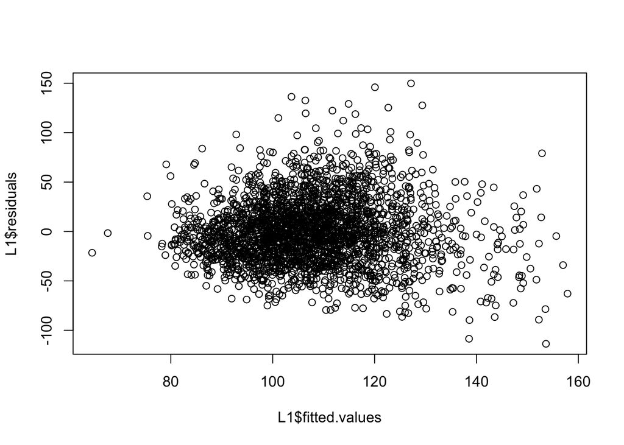

```r
plot(L1$fitted.values,L1$residuals)
```

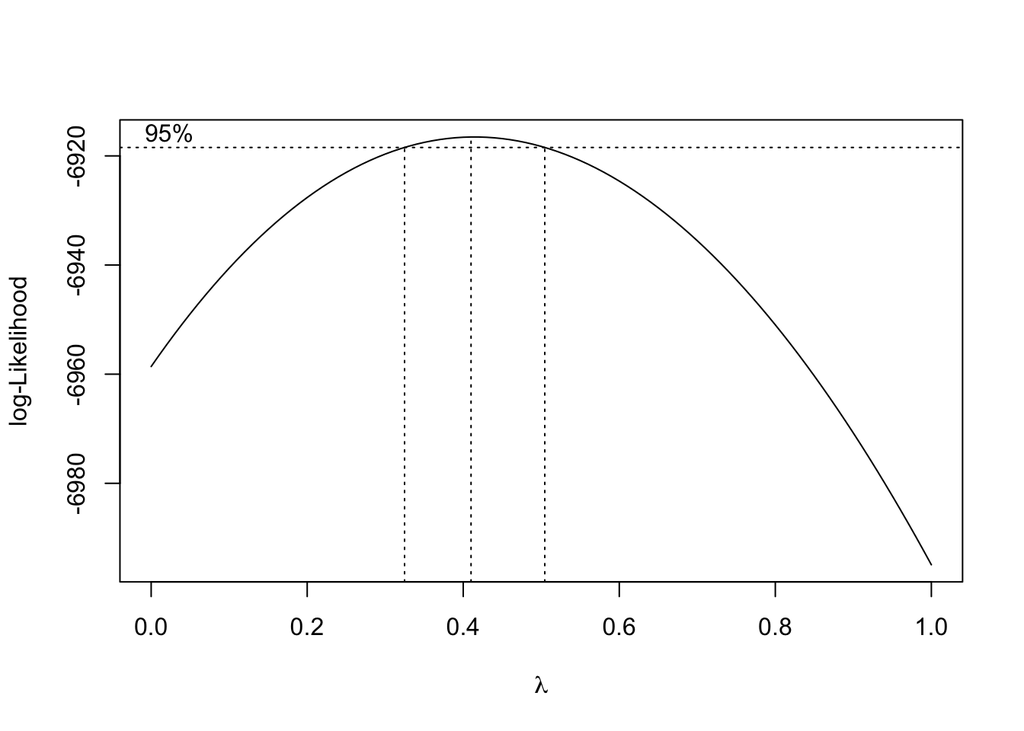

```r
## Here, it seems that some transformations should be used upon ldl. Here
## we do the Box-Cox test.
boxcox(L1,plotit=TRUE,lambda=seq(0,1,1/100))
```

```r
## Here it seems that lambda=0.5 is the best choice, that is, to use sqrt(ldl).
## Here we make the transformation and then do the regression again.
L2=lm(sqrt(ldl)~.,data=DT)
summary(L2)
```

```
##
## Call:
## lm(formula = sqrt(ldl) ~ ., data = DT)
##
## Residuals:
##     Min      1Q  Median      3Q     Max
## -6.1905 -1.0601  0.0021  1.0178  5.5148
##
## Coefficients:
##                 Estimate Std. Error t value Pr(>|t|)
## (Intercept)    1.005e+01  2.158e+00   4.658 3.36e-06 ***
## gender2        5.965e-02  8.886e-02   0.671   0.5021
## age            8.429e-03  1.860e-03   4.531 6.15e-06 ***
## race2          1.830e-01  1.161e-01   1.576   0.1151
## race3          8.270e-02  1.007e-01   0.821   0.4116
## race4          1.305e-01  1.099e-01   1.187   0.2354
## race6          2.302e-01  1.317e-01   1.748   0.0806 .
## race7          2.744e-01  1.866e-01   1.470   0.1416
## intake_fat     4.259e-04  1.093e-03   0.390   0.6968
## intake_chol   -8.613e-05  2.115e-04  -0.407   0.6838
## systolic      -3.532e-04  2.211e-03  -0.160   0.8731
## diastolic      2.006e-02  2.763e-03   7.261 5.11e-13 ***
## triglycerides  6.538e-03  5.472e-04  11.948  < 2e-16 ***
## weight         1.492e-02  1.280e-02   1.165   0.2440
## height        -1.644e-02  1.297e-02  -1.268   0.2050
## bmi           -2.700e-02  3.566e-02  -0.757   0.4489
## ---
## Signif. codes:  0 '***' 0.001 '**' 0.01 '*' 0.05 '.' 0.1 ' ' 1
##
## Residual standard error: 1.604 on 2487 degrees of freedom
## Multiple R-squared:  0.1327, Adjusted R-squared:  0.1275
## F-statistic: 25.38 on 15 and 2487 DF,  p-value: < 2.2e-16
```

```r
## There are too many variables in the regression model, so here we will do
## the model selection and choose the variables. Here we do both the forward
## and backward selections.
L3_a=step(L2,direction='forward')
```

```
## Start:  AIC=2380.04
## sqrt(ldl) ~ gender + age + race + intake_fat + intake_chol +
##     systolic + diastolic + triglycerides + weight + height +
##     bmi
```

```r
L3_b=step(L2,direction='backward')
```

```
## Start:  AIC=2380.04
## sqrt(ldl) ~ gender + age + race + intake_fat + intake_chol +
##     systolic + diastolic + triglycerides + weight + height +
##     bmi
##
##                 Df Sum of Sq    RSS    AIC
## - race           5     13.64 6409.0 2375.4
## - systolic       1      0.07 6395.5 2378.1
## - intake_fat     1      0.39 6395.8 2378.2
## - intake_chol    1      0.43 6395.8 2378.2
## - gender         1      1.16 6396.6 2378.5
## - bmi            1      1.47 6396.9 2378.6
## - weight         1      3.49 6398.9 2379.4
## - height         1      4.13 6399.5 2379.7
## <none>                       6395.4 2380.0
## - age            1     52.79 6448.2 2398.6
## - diastolic      1    135.59 6531.0 2430.6
## - triglycerides  1    367.08 6762.5 2517.7
##
## Step:  AIC=2375.37
## sqrt(ldl) ~ gender + age + intake_fat + intake_chol + systolic +
##     diastolic + triglycerides + weight + height + bmi
##
##                 Df Sum of Sq    RSS    AIC
## - systolic       1      0.09 6409.1 2373.4
## - intake_fat     1      0.14 6409.2 2373.4
## - intake_chol    1      0.40 6409.4 2373.5
## - gender         1      1.43 6410.5 2373.9
## - bmi            1      1.95 6411.0 2374.1
## - weight         1      3.95 6413.0 2374.9
## - height         1      4.35 6413.4 2375.1
## <none>                       6409.0 2375.4
## - age            1     54.06 6463.1 2394.4
## - diastolic      1    144.08 6553.1 2429.0
## - triglycerides  1    384.56 6793.6 2519.2
##
## Step:  AIC=2373.41
## sqrt(ldl) ~ gender + age + intake_fat + intake_chol + diastolic +
##     triglycerides + weight + height + bmi
##
```

[output cut: 49 more lines]

```
## - height         1      5.36 6416.6 2368.3
## - age            1     65.04 6476.2 2391.5
## - diastolic      1    159.26 6570.5 2427.6
## - triglycerides  1    383.55 6794.8 2511.7
##
## Step:  AIC=2366.89
## sqrt(ldl) ~ age + diastolic + triglycerides + weight + height
##
##                 Df Sum of Sq    RSS    AIC
## <none>                       6412.9 2366.9
## - height         1     13.59 6426.5 2370.2
## - weight         1     21.39 6434.3 2373.2
## - age            1     63.64 6476.6 2389.6
## - diastolic      1    158.13 6571.1 2425.9
## - triglycerides  1    388.91 6801.8 2512.3
```

```r
summary(L3_a)
```

```
##
## Call:
## lm(formula = sqrt(ldl) ~ gender + age + race + intake_fat + intake_chol +
##     systolic + diastolic + triglycerides + weight + height +
##     bmi, data = DT)
##
## Residuals:
##     Min      1Q  Median      3Q     Max
## -6.1905 -1.0601  0.0021  1.0178  5.5148
##
## Coefficients:
##                 Estimate Std. Error t value Pr(>|t|)
## (Intercept)    1.005e+01  2.158e+00   4.658 3.36e-06 ***
## gender2        5.965e-02  8.886e-02   0.671   0.5021
## age            8.429e-03  1.860e-03   4.531 6.15e-06 ***
## race2          1.830e-01  1.161e-01   1.576   0.1151
## race3          8.270e-02  1.007e-01   0.821   0.4116
## race4          1.305e-01  1.099e-01   1.187   0.2354
## race6          2.302e-01  1.317e-01   1.748   0.0806 .
## race7          2.744e-01  1.866e-01   1.470   0.1416
## intake_fat     4.259e-04  1.093e-03   0.390   0.6968
## intake_chol   -8.613e-05  2.115e-04  -0.407   0.6838
## systolic      -3.532e-04  2.211e-03  -0.160   0.8731
## diastolic      2.006e-02  2.763e-03   7.261 5.11e-13 ***
## triglycerides  6.538e-03  5.472e-04  11.948  < 2e-16 ***
## weight         1.492e-02  1.280e-02   1.165   0.2440
## height        -1.644e-02  1.297e-02  -1.268   0.2050
## bmi           -2.700e-02  3.566e-02  -0.757   0.4489
## ---
## Signif. codes:  0 '***' 0.001 '**' 0.01 '*' 0.05 '.' 0.1 ' ' 1
##
## Residual standard error: 1.604 on 2487 degrees of freedom
## Multiple R-squared:  0.1327, Adjusted R-squared:  0.1275
## F-statistic: 25.38 on 15 and 2487 DF,  p-value: < 2.2e-16
```

```r
summary(L3_b)
```

```
##
## Call:
## lm(formula = sqrt(ldl) ~ age + diastolic + triglycerides + weight +
##     height, data = DT)
##
## Residuals:
##     Min      1Q  Median      3Q     Max
## -6.2425 -1.0646  0.0056  1.0406  5.5286
##
## Coefficients:
##                 Estimate Std. Error t value Pr(>|t|)
## (Intercept)    8.8488834  0.5771649  15.332  < 2e-16 ***
## age            0.0079968  0.0016065   4.978 6.87e-07 ***
## diastolic      0.0203065  0.0025879   7.847 6.28e-15 ***
## triglycerides  0.0064965  0.0005279  12.306  < 2e-16 ***
## weight         0.0049061  0.0017000   2.886  0.00394 **
## height        -0.0083689  0.0036375  -2.301  0.02149 *
## ---
## Signif. codes:  0 '***' 0.001 '**' 0.01 '*' 0.05 '.' 0.1 ' ' 1
##
## Residual standard error: 1.603 on 2497 degrees of freedom
## Multiple R-squared:  0.1304, Adjusted R-squared:  0.1286
## F-statistic: 74.87 on 5 and 2497 DF,  p-value: < 2.2e-16
```

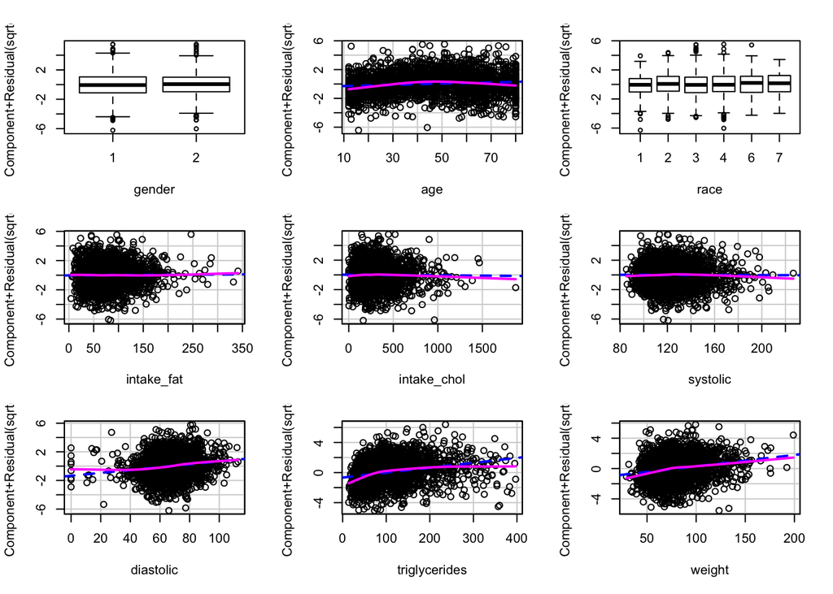

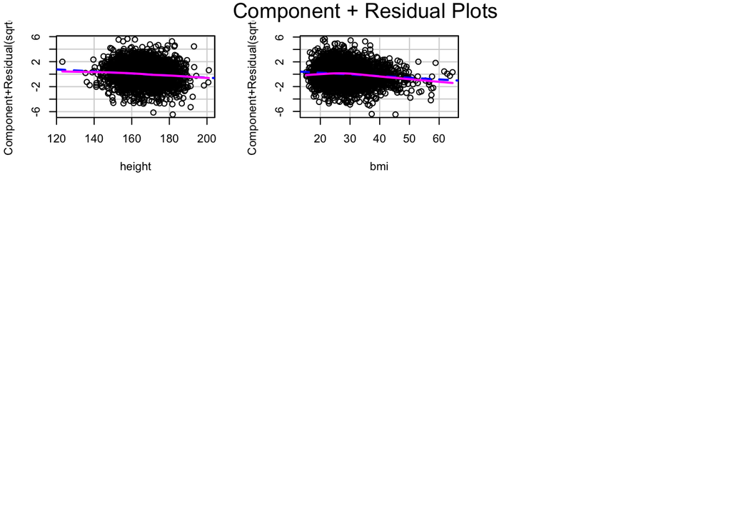

```r
## By the way, in the models before, we didn't consider transformations
## upon predictors; in the coming part, we will consider adding some
## nonlinear terms.
crPlots(L2)
```

```r
## From the partial residual plots, we can find out that for triglycerides and age,
## some nonlinear transformation forms should be add. We add this term, and the
## regression result is as following:
L4=lm(sqrt(ldl)~gender+age+race+intake_fat+intake_chol+systolic+diastolic+
             weight+height+bmi+triglycerides+I(triglycerides^2)+I(age^2),data=DT)
summary(L4)
```

```
##
## Call:
## lm(formula = sqrt(ldl) ~ gender + age + race + intake_fat + intake_chol +
##     systolic + diastolic + weight + height + bmi + triglycerides +
##     I(triglycerides^2) + I(age^2), data = DT)
##
## Residuals:
##     Min      1Q  Median      3Q     Max
## -5.2795 -0.9630 -0.0056  0.9958  5.4639
##
## Coefficients:
##                      Estimate Std. Error t value Pr(>|t|)
## (Intercept)         1.155e+01  2.065e+00   5.593 2.47e-08 ***
## gender2            -7.780e-02  8.572e-02  -0.908  0.36421
## age                 1.075e-01  8.753e-03  12.282  < 2e-16 ***
## race2               8.510e-02  1.109e-01   0.767  0.44310
## race3               1.954e-01  9.673e-02   2.020  0.04349 *
## race4               2.324e-01  1.053e-01   2.207  0.02739 *
## race6               1.303e-01  1.258e-01   1.035  0.30054
## race7               3.578e-01  1.782e-01   2.008  0.04472 *
## intake_fat         -7.455e-05  1.043e-03  -0.071  0.94303
## intake_chol        -1.705e-04  2.019e-04  -0.844  0.39857
## systolic            3.840e-03  2.141e-03   1.794  0.07298 .
## diastolic           6.303e-03  2.858e-03   2.206  0.02750 *
## weight              2.520e-02  1.223e-02   2.060  0.03950 *
## height             -3.457e-02  1.246e-02  -2.775  0.00556 **
## bmi                -7.122e-02  3.413e-02  -2.087  0.03703 *
## triglycerides       2.150e-02  1.660e-03  12.953  < 2e-16 ***
## I(triglycerides^2) -5.019e-05  5.005e-06 -10.027  < 2e-16 ***
## I(age^2)           -1.138e-03  9.593e-05 -11.862  < 2e-16 ***
## ---
## Signif. codes:  0 '***' 0.001 '**' 0.01 '*' 0.05 '.' 0.1 ' ' 1
##
## Residual standard error: 1.53 on 2485 degrees of freedom
## Multiple R-squared:  0.2114, Adjusted R-squared:  0.206
## F-statistic:  39.2 on 17 and 2485 DF,  p-value: < 2.2e-16
```

```r
## Just the same, do the model selection.
L5_a=step(L4,direction='forward')
```

```
## Start:  AIC=2145.93
## sqrt(ldl) ~ gender + age + race + intake_fat + intake_chol +
##     systolic + diastolic + weight + height + bmi + triglycerides +
##     I(triglycerides^2) + I(age^2)
```

```r
L5_b=step(L4,direction='backward')
```

```
## Start:  AIC=2145.93
## sqrt(ldl) ~ gender + age + race + intake_fat + intake_chol +
##     systolic + diastolic + weight + height + bmi + triglycerides +
##     I(triglycerides^2) + I(age^2)
##
##                      Df Sum of Sq    RSS    AIC
## - race                5     17.66 5832.7 2143.5
## - intake_fat          1      0.01 5815.1 2143.9
## - intake_chol         1      1.67 5816.7 2144.7
## - gender              1      1.93 5817.0 2144.8
## <none>                            5815.0 2145.9
## - systolic            1      7.53 5822.6 2147.2
## - weight              1      9.93 5825.0 2148.2
## - bmi                 1     10.19 5825.2 2148.3
## - diastolic           1     11.38 5826.4 2148.8
## - height              1     18.02 5833.1 2151.7
## - I(triglycerides^2)  1    235.29 6050.3 2243.2
## - I(age^2)            1    329.26 6144.3 2281.8
## - age                 1    353.01 6168.1 2291.4
## - triglycerides       1    392.60 6207.6 2307.4
##
## Step:  AIC=2143.52
## sqrt(ldl) ~ gender + age + intake_fat + intake_chol + systolic +
##     diastolic + weight + height + bmi + triglycerides + I(triglycerides^2) +
##     I(age^2)
##
##                      Df Sum of Sq    RSS    AIC
## - intake_fat          1      0.01 5832.7 2141.5
## - gender              1      0.22 5832.9 2141.6
## - intake_chol         1      2.70 5835.4 2142.7
## <none>                            5832.7 2143.5
## - systolic            1      8.37 5841.1 2145.1
## - weight              1     10.83 5843.5 2146.2
## - bmi                 1     11.15 5843.9 2146.3
## - diastolic           1     11.83 5844.5 2146.6
## - height              1     15.11 5847.8 2148.0
## - I(triglycerides^2)  1    233.60 6066.3 2239.8
## - I(age^2)            1    329.37 6162.1 2279.0
## - age                 1    351.52 6184.2 2288.0
## - triglycerides       1    396.27 6229.0 2306.0
```

[output cut: 37 more lines]

```
## Step:  AIC=2139.18
## sqrt(ldl) ~ age + systolic + diastolic + weight + height + bmi +
##     triglycerides + I(triglycerides^2) + I(age^2)
##
##                      Df Sum of Sq    RSS    AIC
## <none>                            5836.6 2139.2
## - systolic            1      9.00 5845.6 2141.0
## - weight              1     10.91 5847.5 2141.8
## - bmi                 1     11.41 5848.0 2142.1
## - diastolic           1     12.16 5848.7 2142.4
## - height              1     15.47 5852.1 2143.8
## - I(triglycerides^2)  1    234.65 6071.2 2235.8
## - I(age^2)            1    328.68 6165.3 2274.3
## - age                 1    351.28 6187.9 2283.5
## - triglycerides       1    399.35 6235.9 2302.8
```

```r
summary(L5_a)
```

```
##
## Call:
## lm(formula = sqrt(ldl) ~ gender + age + race + intake_fat + intake_chol +
##     systolic + diastolic + weight + height + bmi + triglycerides +
##     I(triglycerides^2) + I(age^2), data = DT)
##
## Residuals:
##     Min      1Q  Median      3Q     Max
## -5.2795 -0.9630 -0.0056  0.9958  5.4639
##
## Coefficients:
##                      Estimate Std. Error t value Pr(>|t|)
## (Intercept)         1.155e+01  2.065e+00   5.593 2.47e-08 ***
## gender2            -7.780e-02  8.572e-02  -0.908  0.36421
## age                 1.075e-01  8.753e-03  12.282  < 2e-16 ***
## race2               8.510e-02  1.109e-01   0.767  0.44310
## race3               1.954e-01  9.673e-02   2.020  0.04349 *
## race4               2.324e-01  1.053e-01   2.207  0.02739 *
## race6               1.303e-01  1.258e-01   1.035  0.30054
## race7               3.578e-01  1.782e-01   2.008  0.04472 *
## intake_fat         -7.455e-05  1.043e-03  -0.071  0.94303
## intake_chol        -1.705e-04  2.019e-04  -0.844  0.39857
## systolic            3.840e-03  2.141e-03   1.794  0.07298 .
## diastolic           6.303e-03  2.858e-03   2.206  0.02750 *
## weight              2.520e-02  1.223e-02   2.060  0.03950 *
## height             -3.457e-02  1.246e-02  -2.775  0.00556 **
## bmi                -7.122e-02  3.413e-02  -2.087  0.03703 *
## triglycerides       2.150e-02  1.660e-03  12.953  < 2e-16 ***
## I(triglycerides^2) -5.019e-05  5.005e-06 -10.027  < 2e-16 ***
## I(age^2)           -1.138e-03  9.593e-05 -11.862  < 2e-16 ***
## ---
## Signif. codes:  0 '***' 0.001 '**' 0.01 '*' 0.05 '.' 0.1 ' ' 1
##
## Residual standard error: 1.53 on 2485 degrees of freedom
## Multiple R-squared:  0.2114, Adjusted R-squared:  0.206
## F-statistic:  39.2 on 17 and 2485 DF,  p-value: < 2.2e-16
```

```r
summary(L5_b)
```

```
##
## Call:
## lm(formula = sqrt(ldl) ~ age + systolic + diastolic + weight +
##     height + bmi + triglycerides + I(triglycerides^2) + I(age^2),
##     data = DT)
##
## Residuals:
##     Min      1Q  Median      3Q     Max
## -5.2347 -0.9663 -0.0208  1.0166  5.4756
##
## Coefficients:
##                      Estimate Std. Error t value Pr(>|t|)
## (Intercept)         1.109e+01  2.011e+00   5.516 3.82e-08 ***
## age                 1.047e-01  8.550e-03  12.249  < 2e-16 ***
## systolic            4.101e-03  2.091e-03   1.961   0.0500 *
## diastolic           6.455e-03  2.832e-03   2.279   0.0228 *
## weight              2.636e-02  1.221e-02   2.159   0.0310 *
## height             -3.121e-02  1.214e-02  -2.571   0.0102 *
## bmi                -7.503e-02  3.398e-02  -2.208   0.0274 *
## triglycerides       2.116e-02  1.620e-03  13.060  < 2e-16 ***
## I(triglycerides^2) -4.954e-05  4.948e-06 -10.011  < 2e-16 ***
## I(age^2)           -1.105e-03  9.325e-05 -11.849  < 2e-16 ***
## ---
## Signif. codes:  0 '***' 0.001 '**' 0.01 '*' 0.05 '.' 0.1 ' ' 1
##
## Residual standard error: 1.53 on 2493 degrees of freedom
## Multiple R-squared:  0.2085, Adjusted R-squared:  0.2057
## F-statistic: 72.98 on 9 and 2493 DF,  p-value: < 2.2e-16
```

```r
## By the way, we will have the linear mixed model upon the dataset:
LM=lmer(ldl~age+intake_fat+intake_chol+systolic+diastolic+
          weight+height+bmi+triglycerides+(1|gender)+(1|race),data=DT)
```

```
## boundary (singular) fit: see ?isSingular
```

```r
summary(LM)
```

```
## Linear mixed model fit by REML ['lmerMod']
## Formula: ldl ~ age + intake_fat + intake_chol + systolic + diastolic +
##     weight + height + bmi + triglycerides + (1 | gender) + (1 |      race)
##    Data: DT
##
## REML criterion at convergence: 24691.1
##
## Scaled residuals:
##     Min      1Q  Median      3Q     Max
## -3.3525 -0.6773 -0.0739  0.5917  4.4911
##
## Random effects:
##  Groups   Name        Variance Std.Dev.
##  race     (Intercept)    0.695  0.8337
##  gender   (Intercept)    0.000  0.0000
##  Residual             1111.545 33.3398
## Number of obs: 2503, groups:  race, 6; gender, 2
##
## Fixed effects:
##                 Estimate Std. Error t value
## (Intercept)   111.161885  43.863459   2.534
## age             0.175052   0.038036   4.602
## intake_fat      0.001994   0.022497   0.089
## intake_chol    -0.001512   0.004350  -0.348
## systolic       -0.009931   0.045057  -0.220
## diastolic       0.411477   0.056723   7.254
## weight          0.309732   0.265604   1.166
## height         -0.351071   0.264700  -1.326
## bmi            -0.630334   0.737863  -0.854
## triglycerides   0.141182   0.011105  12.714
##
## Correlation of Fixed Effects:
##             (Intr) age    intk_f intk_c systlc distlc weight height bmi
## age          0.073
## intake_fat   0.047  0.053
## intake_chol -0.011 -0.066 -0.596
## systolic    -0.074 -0.458  0.027  0.015
## diastolic    0.011  0.102 -0.063  0.033 -0.302
## weight       0.961  0.071  0.017 -0.012 -0.009  0.022
## height      -0.992 -0.054 -0.071  0.009 -0.003 -0.051 -0.963
## bmi         -0.957 -0.081 -0.016  0.004 -0.003 -0.040 -0.991  0.955
## triglycerds -0.073 -0.134  0.053 -0.039 -0.047 -0.081 -0.093  0.077  0.067
## convergence code: 0
## boundary (singular) fit: see ?isSingular
```

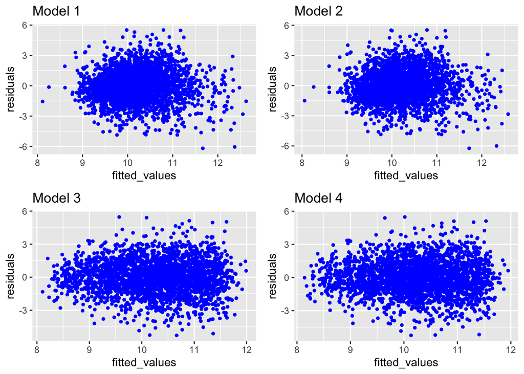

```r
## Additional Analysis: Some extra graphs

## Libraries: -------------------------------------------------------------------------
library(ggplot2)
library(gridExtra)
## 80: --------------------------------------------------------------------------------

## Graph 1: Some Diagnosis upon these models
### F1: Checking error assumptions--residual plots
R1=data.table(fitted_values=L2$fitted.values,residuals=L2$residuals)
R2=data.table(fitted_values=L3_b$fitted.values,residuals=L3_b$residuals)
R3=data.table(fitted_values=L4$fitted.values,residuals=L4$residuals)
R4=data.table(fitted_values=L5_b$fitted.values,residuals=L5_b$residuals)
rs1=ggplot(R1,aes(x=fitted_values,y=residuals))+geom_point(size=1,colour='blue')+
  labs(title='Model 1')
rs2=ggplot(R2,aes(x=fitted_values,y=residuals))+geom_point(size=1,colour='blue')+
  labs(title='Model 2')
rs3=ggplot(R3,aes(x=fitted_values,y=residuals))+geom_point(size=1,colour='blue')+
  labs(title='Model 3')
rs4=ggplot(R4,aes(x=fitted_values,y=residuals))+geom_point(size=1,colour='blue')+
  labs(title='Model 4')
grid.arrange(rs1,rs2,rs3,rs4,nrow=2)
```

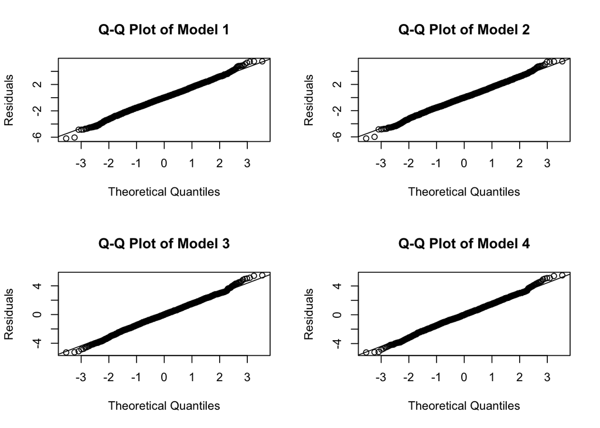

```r
## Graph 2: QQ-plots of the models
par(mfrow=c(2,2))
qqnorm(R1$residuals, ylab="Residuals",main='Q-Q Plot of Model 1')
qqline(R1$residuals)
qqnorm(R2$residuals, ylab="Residuals",main='Q-Q Plot of Model 2')
qqline(R2$residuals)
qqnorm(R3$residuals, ylab="Residuals",main='Q-Q Plot of Model 3')
qqline(R3$residuals)
qqnorm(R4$residuals, ylab="Residuals",main='Q-Q Plot of Model 4')
qqline(R4$residuals)
```

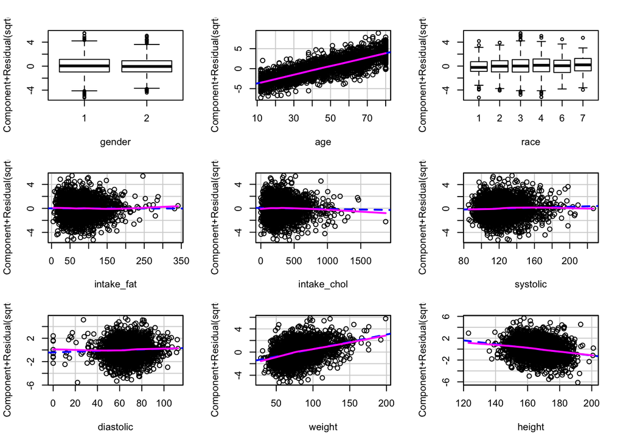

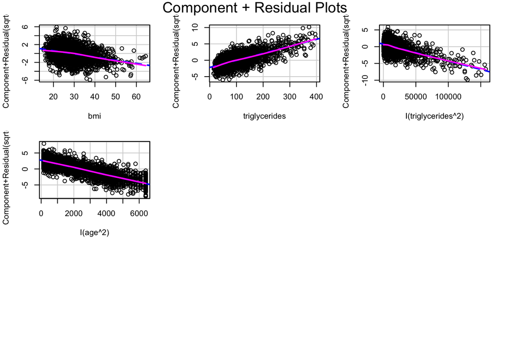

```r
## Graph 3: Partial Residual Plots upon Model 3 and 4
crPlots(L4)
```

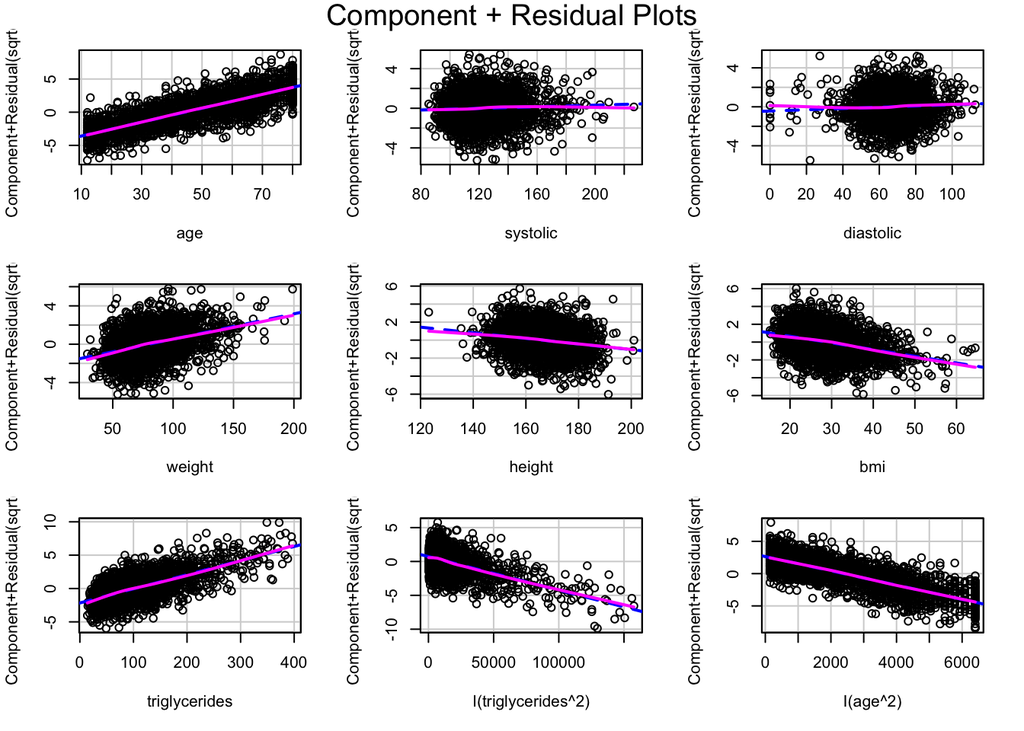

```r
crPlots(L5_b)
```

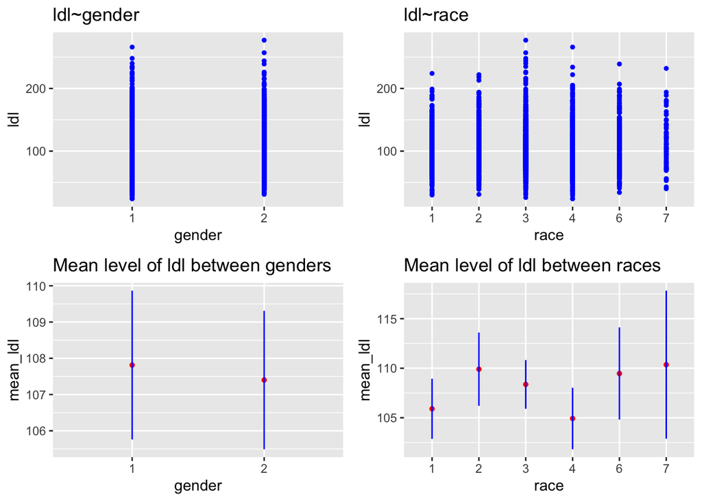

```r
## Graph 4: Relationships between ldl and gender/race.  We have the mean level of
## ldl between different gender and race (For CI, we will use the JackKnife
## standard error.)
Mean_JK = function(x){
  lx=length(x)
  MX=matrix(rep(x,rep(lx-1,lx)),ncol=lx,byrow=TRUE)
  theta=colMeans(MX)
  mean_theta=mean(theta)
  std_theta={(lx-1)/lx*sum((theta-mean_theta)^2)}^(1/2)
  std_theta
}

Gend=DT[,.(gender,ldl)]
Race=DT[,.(race,ldl)]
MG=Gend[,.(mean_ldl=mean(ldl),l_ldl=mean(ldl)+qnorm(0.025)*Mean_JK(ldl),
           r_ldl=mean(ldl)+qnorm(0.975)*Mean_JK(ldl)),by=gender]
MR=Race[,.(mean_ldl=mean(ldl),l_ldl=mean(ldl)+qnorm(0.025)*Mean_JK(ldl),
           r_ldl=mean(ldl)+qnorm(0.975)*Mean_JK(ldl)),by=race]

gend=ggplot(Gend,aes(x=gender,y=ldl))+geom_point(size=1,colour='blue')+
  labs(title='ldl~gender')
race=ggplot(Race,aes(x=race,y=ldl))+geom_point(size=1,colour='blue')+
  labs(title='ldl~race')
mean_gend=ggplot(MG,aes(x=gender,y=mean_ldl))+geom_point(shape=16,col='red')+
  geom_segment(data=MG,mapping=aes(x=gender,xend=gender,y=l_ldl,yend=r_ldl),
               col='blue')+
  labs(title = 'Mean level of ldl between genders')
mean_race=ggplot(MR,aes(x=race,y=mean_ldl))+geom_point(shape=16,col='red')+
  geom_segment(data=MR,mapping=aes(x=race,xend=race,y=l_ldl,yend=r_ldl),
               col='blue')+
  labs(title = 'Mean level of ldl between races')

grid.arrange(gend,race,mean_gend,mean_race,nrow=2)
```